# Global AI Global Index 🤖

🔗**Data Source:** https://www.kaggle.com/datasets/katerynameleshenko/ai-index

📌 The **Global AI Index** includes seven indicators affecting the Index on 62 countries, as well as general information about the countries (region, cluster, income group and political regime). The Global AI Index is the first index to benchmark nations on their level of *investment*, innovation and implementation of artificial intelligence.

🛠️ **Implementation** - represents the application of artificial intelligence by professionals in various sectors, such as businesses, governments, and communities.

- **Talent** *indicator focuses on the availability of skilled practitioners for the provision of artificial intelligence solutions.*
- **Infrastructure** *indicator focuses on the reliability and scale of access infrastructure, from electricity and internet, to super computing capabilities.*
- **Operating Environment** *indicator focuses on the regulatory context, and public opinion surrounding artificial intelligence.*

💡 **Innovation** - reflects the progress made in technology and methodology, which signify the potential for artificial intelligence to evolve and improve.

- **Research** *indicator focuses on the extent of specialist research and researchers; investigating the amount of publications and citations in credible academic journals.*
- **Development** *indicator focuses on the development of fundamental platforms and algorithms upon which innovative artificial intelligence projects rely.*

💸 **Investment** - reflects financial and procedural commitments to artificial intelligence

- **Government Strategy** *indicator focuses on the depth of commitment from national government to artificial intelligence; investigating spending commitments and national strategies.*
- **Commercial** *indicator focuses on the level of startup activity, investment and business initiatives based on artificial intelligence.*

**📊 Data Columns:**

1. **Country**: The name of the country or nation being evaluated in the dataset.
2. **Talent**: A measure of the country's talent pool or human resources related to AI, indicating the quality and quantity of AI professionals and experts.
3. **Infrastructure**: An assessment of the country's AI-related infrastructure, which includes factors like technological capabilities, research facilities, and computing resources.
4. **Operating Environment**: An evaluation of the overall business and regulatory environment for AI within the country, including factors that impact AI adoption and development.
5. **Research**: An assessment of the country's contributions to AI research, including the quality and quantity of research papers, patents, and academic institutions involved in AI research.
6. **Development**: A measure of the country's AI development activities, encompassing factors like innovation, startups, and the development of AI technologies and applications.
7. **Government Strategy**: An evaluation of the government's strategic initiatives and policies related to AI, which can significantly impact the growth and direction of AI within the country.
8. **Commercial**: An assessment of the country's commercial AI ecosystem, including the presence of AI companies, market opportunities, and the business environment for AI-related ventures.
9. **Total Score**: The cumulative score or ranking that summarizes the country's performance across all the mentioned factors, providing an overall assessment of its AI capabilities.
10. **Region**: The geographical region to which the country belongs (e.g., Americas, Asia-Pacific, Europe, Middle East, Africa).
11. **Cluster**: A grouping or classification of the country based on its AI performance or characteristics (e.g., Power players, Traditional champions, Rising stars, Waking up, Nascent).
12. **Income Group**: The income group to which the country belongs (e.g., High income, Upper middle income, Lower middle income).
13. **Political Regime**: The political regime or system of governance in the country (e.g., Liberal democracy, Closed autocracy, Electoral democracy).

**🎯 Load the Data Files**

```python
import pandas as pd
import matplotlib.pyplot as plt
import seaborn as sns

# Data Loading:
df = pd.read_csv("AI_index_db.csv")
df
```

|  | Country | Talent | Infrastructure | Operating Environment | Research | Development | Government Strategy | Commercial | Total score | Region | Cluster | Income group | Political regime |
| --- | --- | --- | --- | --- | --- | --- | --- | --- | --- | --- | --- | --- | --- |
| 0 | United States of America | 100.00 | 94.02 | 64.56 | 100.00 | 100.00 | 77.39 | 100.00 | 100.00 | Americas | Power players | High | Liberal democracy |
| 1 | China | 16.51 | 100.00 | 91.57 | 71.42 | 79.97 | 94.87 | 44.02 | 62.92 | Asia-Pacific | Power players | Upper middle | Closed autocracy |
| 2 | United Kingdom | 39.65 | 71.43 | 74.65 | 36.50 | 25.03 | 82.82 | 18.91 | 40.93 | Europe | Traditional champions | High | Liberal democracy |
| 3 | Canada | 31.28 | 77.05 | 93.94 | 30.67 | 25.78 | 100.00 | 14.88 | 40.19 | Americas | Traditional champions | High | Liberal democracy |
| 4 | Israel | 35.76 | 67.58 | 82.44 | 32.63 | 27.96 | 43.91 | 27.33 | 39.89 | Middle East | Rising stars | High | Liberal democracy |
| ... | ... | ... | ... | ... | ... | ... | ... | ... | ... | ... | ... | ... | ... |
| 57 | Sri Lanka | 6.27 | 34.64 | 35.79 | 0.12 | 0.95 | 35.57 | 0.09 | 6.62 | Asia-Pacific | Nascent | Lower middle | Electoral democracy |
| 58 | Egypt | 1.11 | 38.84 | 0.00 | 2.08 | 1.54 | 68.72 | 0.31 | 4.83 | Middle East | Nascent | Lower middle | Electoral autocracy |
| 59 | Kenya | 0.75 | 14.11 | 29.84 | 0.07 | 12.15 | 7.75 | 0.31 | 2.30 | Africa | Nascent | Lower middle | Electoral autocracy |
| 60 | Nigeria | 2.74 | 0.00 | 50.10 | 0.45 | 2.06 | 7.75 | 0.33 | 1.38 | Africa | Nascent | Lower middle | Electoral autocracy |
| 61 | Pakistan | 8.00 | 2.43 | 12.48 | 2.17 | 1.09 | 13.92 | 0.27 | 0.00 | Asia-Pacific | Nascent | Lower middle | Electoral autocracy |

62 rows × 13 columns

**🎯 Print Summary Statistics**

```python
# Display basic statistics
print(df.describe())
```

```
           Talent  Infrastructure  Operating Environment    Research  \
count   62.000000       62.000000              62.000000   62.000000
mean    16.803065       63.503710              66.925484   16.610000
std     15.214963       20.217525              20.000424   17.413996
min      0.000000        0.000000               0.000000    0.000000
25%      7.365000       55.857500              58.107500    3.032500
50%     13.445000       65.230000              69.505000   12.930000
75%     24.567500       75.947500              80.500000   25.412500
max    100.000000      100.000000             100.000000  100.000000

       Development  Government Strategy  Commercial  Total score
count    62.000000            62.000000   62.000000    62.000000
mean     14.824677            57.865645    6.171935    23.914677
std      19.419279            26.252448   14.029632    15.123586
min       0.000000             0.000000    0.000000     0.000000
25%       1.202500            41.030000    0.697500    14.805000
50%       9.005000            63.930000    2.585000    23.220000
75%      19.980000            77.952500    5.307500    30.487500
max     100.000000           100.000000  100.000000   100.000000
```

**🎯 Data Cleaning**

```python
# Handle missing values and data formatting if needed.
# Check for missing values
print(df.isnull().sum())
```

```
Country                  0
Talent                   0
Infrastructure           0
Operating Environment    0
Research                 0
Development              0
Government Strategy      0
Commercial               0
Total score              0
Region                   0
Cluster                  0
Income group             0
Political regime         0
dtype: int64
```

**🎯 Filtering and Sorting**

```python
# Top 5 countries with the highest AI Index scores
top_countries = df.nlargest(5, 'Total score')
print("Top 5 Countries:")
print(top_countries[['Country', 'Total score']])

# Bottom 5 countries with the lowest AI Index scores
bottom_countries = df.nsmallest(5, 'Total score')
print("\nBottom 5 Countries:")
print(bottom_countries[['Country', 'Total score']])
```

```
Top 5 Countries:
                    Country  Total score
0  United States of America       100.00
1                     China        62.92
2            United Kingdom        40.93
3                    Canada        40.19
4                    Israel        39.89

Bottom 5 Countries:
      Country  Total score
61   Pakistan         0.00
60    Nigeria         1.38
59      Kenya         2.30
58      Egypt         4.83
57  Sri Lanka         6.62
```

**🎯 Creating Plots**

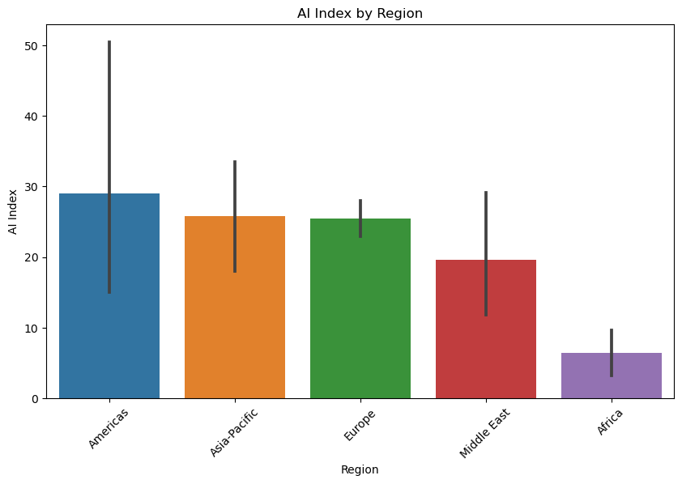

```python
# Bar Chart of AI Index by Region
plt.figure(figsize=(10, 6))
sns.barplot(x='Region', y='Total score', data=df)
plt.xlabel('Region')
plt.ylabel('AI Index')
plt.title('AI Index by Region')
plt.xticks(rotation=45)
plt.show()
```

**🎯 Finding Correlations**

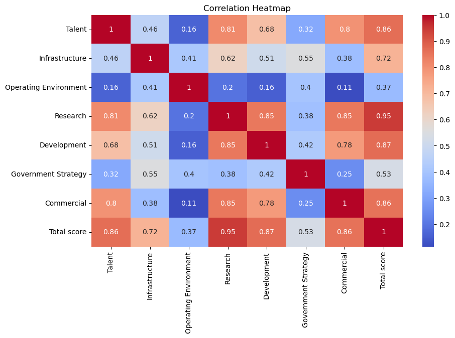

```python
# Calculate correlations between variables.

# Calculate correlation matrix
correlation_matrix = df.corr(numeric_only=True)

# Create a correlation heatmap
plt.figure(figsize=(10, 6))
sns.heatmap(correlation_matrix, annot=True, cmap='coolwarm')
plt.title('Correlation Heatmap')
plt.show()
```